# Project_1

Beija

2025-04-19

Due to a shared understanding that salaries for data scientists vary significantly across the globe, as well as additional factors such as the Great Recession and market competitiveness, what is the salary range necessary to attract top talent for positions within the United States?

What are the cost differences between domestic and offshore hires?

What salary should a growing company offer in order to attract top data scientist talent, whether based in the United States or offshore, within the context of today’s competitive market?

What is the competitive salary range for a full-time data scientist in the United States compared to other global regions?

Additionally, it would be beneficial to specify the salary ranges for both entry-level and senior-level positions, as these distinctions significantly influence hiring decisions.

```r
library(readr)
library(dplyr)
salary_data <- read_csv("r project data-1.csv")
str(salary_data)
```

```
## spc_tbl_ [607 × 12] (S3: spec_tbl_df/tbl_df/tbl/data.frame)
##  $ ...1              : num [1:607] 0 1 2 3 4 5 6 7 8 9 ...
##  $ work_year         : num [1:607] 2020 2020 2020 2020 2020 2020 2020 2020 2020 2020 ...
##  $ experience_level  : chr [1:607] "MI" "SE" "SE" "MI" ...
##  $ employment_type   : chr [1:607] "FT" "FT" "FT" "FT" ...
##  $ job_title         : chr [1:607] "Data Scientist" "Machine Learning Scientist" "Big Data Engineer" "Product Data Analyst" ...
##  $ salary            : num [1:607] 70000 260000 85000 20000 150000 72000 190000 11000000 135000 125000 ...
##  $ salary_currency   : chr [1:607] "EUR" "USD" "GBP" "USD" ...
##  $ salary_in_usd     : num [1:607] 79833 260000 109024 20000 150000 ...
##  $ employee_residence: chr [1:607] "DE" "JP" "GB" "HN" ...
##  $ remote_ratio      : num [1:607] 0 0 50 0 50 100 100 50 100 50 ...
##  $ company_location  : chr [1:607] "DE" "JP" "GB" "HN" ...
##  $ company_size      : chr [1:607] "L" "S" "M" "S" ...
##  - attr(*, "spec")=
##   .. cols(
##   ..   ...1 = col_double(),
##   ..   work_year = col_double(),
##   ..   experience_level = col_character(),
##   ..   employment_type = col_character(),
##   ..   job_title = col_character(),
##   ..   salary = col_double(),
##   ..   salary_currency = col_character(),
##   ..   salary_in_usd = col_double(),
##   ..   employee_residence = col_character(),
##   ..   remote_ratio = col_double(),
##   ..   company_location = col_character(),
##   ..   company_size = col_character()
##   .. )
##  - attr(*, "problems")=<externalptr>
```

```r
# Convert to factors
salary_data$experience_level <- as.factor(salary_data$experience_level)
salary_data$employment_type <- as.factor(salary_data$employment_type)
salary_data$job_title <- as.factor(salary_data$job_title)
salary_data$salary_currency <- as.factor(salary_data$salary_currency)
salary_data$employee_residence <- as.factor(salary_data$employee_residence)
salary_data$company_location <- as.factor(salary_data$company_location)
salary_data$company_size <- as.factor(salary_data$company_size)
```

Data Analysis

```r
library (ggplot2)
summary(salary_data)
```

```
##       ...1         work_year    experience_level employment_type
##  Min.   :  0.0   Min.   :2020   EN: 88           CT:  5
##  1st Qu.:151.5   1st Qu.:2021   EX: 26           FL:  4
##  Median :303.0   Median :2022   MI:213           FT:588
##  Mean   :303.0   Mean   :2021   SE:280           PT: 10
##  3rd Qu.:454.5   3rd Qu.:2022
##  Max.   :606.0   Max.   :2022
##
##                      job_title       salary         salary_currency
##  Data Scientist           :143   Min.   :    4000   USD    :398
##  Data Engineer            :132   1st Qu.:   70000   EUR    : 95
##  Data Analyst             : 97   Median :  115000   GBP    : 44
##  Machine Learning Engineer: 41   Mean   :  324000   INR    : 27
##  Research Scientist       : 16   3rd Qu.:  165000   CAD    : 18
##  Data Science Manager     : 12   Max.   :30400000   JPY    :  3
##  (Other)                  :166                      (Other): 22
##  salary_in_usd    employee_residence  remote_ratio    company_location
##  Min.   :  2859   US     :332        Min.   :  0.00   US     :355
##  1st Qu.: 62726   GB     : 44        1st Qu.: 50.00   GB     : 47
##  Median :101570   IN     : 30        Median :100.00   CA     : 30
##  Mean   :112298   CA     : 29        Mean   : 70.92   DE     : 28
##  3rd Qu.:150000   DE     : 25        3rd Qu.:100.00   IN     : 24
##  Max.   :600000   FR     : 18        Max.   :100.00   FR     : 15
##                   (Other):129                         (Other):108
##  company_size
##  L:198
##  M:326
##  S: 83
##
##
##
##
```

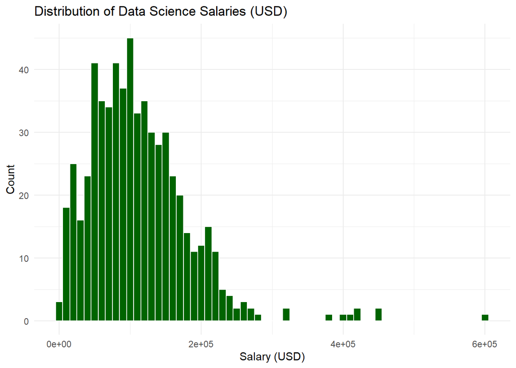

```r
ggplot(salary_data, aes(x = salary_in_usd)) +
  geom_histogram(binwidth = 10000, fill = "darkgreen", color = "white") +
  labs(title = "Distribution of Data Science Salaries (USD)", x = "Salary (USD)", y = "Count") +
  theme_minimal()
```

The graph illustrating the Distribution of Data Science Salaries (USD) indicates that the highest concentration of salaries is observed between $60,000 and $150,000 USD. The modal salary range appears to fall within $100,000 to $130,000, which is likely indicative of the typical salary for data scientists on a global scale. Furthermore, there exists a small subset of individuals who earn significantly high salaries, exceeding $300,000, resulting in a long tail on the right side of the distribution. In order to offer a competitive salary, it is advisable for the CEO to consider a starting range of approximately $100,000 to $150,000 USD, contingent upon the specific location and level of experience of the candidates.

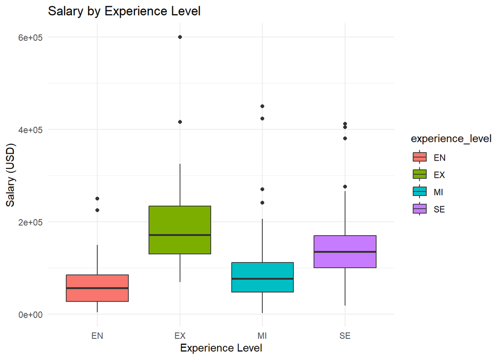

```r
ggplot(salary_data, aes(x = experience_level, y = salary_in_usd, fill = experience_level)) +
  geom_boxplot() +
  labs(title = "Salary by Experience Level", x = "Experience Level", y = "Salary (USD)") +
  theme_minimal()
```

For candidates anticipated to lead a team or assume the position of head of data, it would be prudent to offer a compensation package in the range of $180,000 to $250,000 in order to remain competitive, particularly for positions based in the United States.

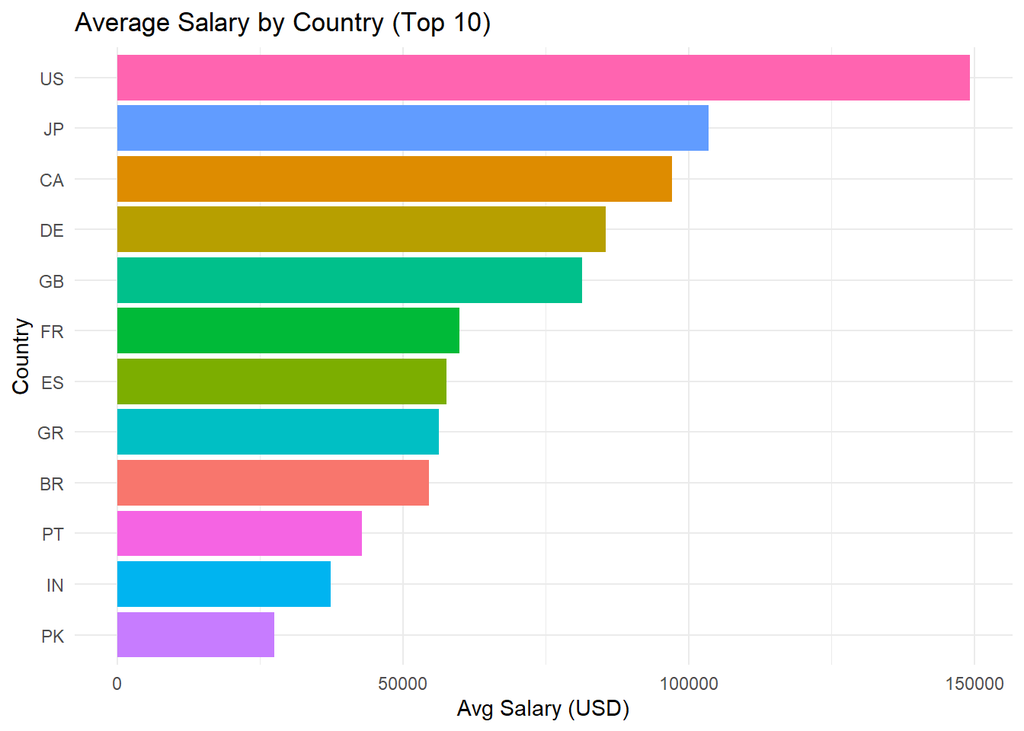

```r
# Top 10 employee residence locations by count
top_countries <- salary_data %>%
  count(employee_residence, sort = TRUE) %>%
  top_n(10, n) %>%
  pull(employee_residence)

# Filtered dataset
filtered_data <- salary_data %>%
  filter(employee_residence %in% top_countries)

# Bar plot of average salary by country
filtered_data %>%
  group_by(employee_residence) %>%
  summarise(avg_salary = mean(salary_in_usd)) %>%
  ggplot(aes(x = reorder(employee_residence, avg_salary), y = avg_salary, fill = employee_residence)) +
  geom_col(show.legend = FALSE) +
  coord_flip() +
  labs(title = "Average Salary by Country (Top 10)", x = "Country", y = "Avg Salary (USD)") +
  theme_minimal()
```

The average salary by county in the United States (U.S.) leads globally, with the highest averages exceeding $140,000 USD. This figure underscores the premium associated with U.S.-based talent.

Conversely, Brazil (BR), Portugal (PT), India (IN), and Pakistan (PK) exhibit considerably lower average salaries. These nations present compelling options for cost-effective offshore hiring; however, variations in experience levels and market maturity should be considered.

Engaging talent within the U.S. typically necessitates a premium investment, often starting at $140,000 USD for experienced professionals. To manage costs while preserving quality, organizations may wish to explore nearshore or offshore alternatives in Europe or Asia, where salaries generally range from $30,000 to $90,000 USD.

Establishing a hybrid team that combines U.S. leadership with offshore support can effectively achieve a balance between quality and cost efficiency.

```r
print(head(salary_data))
```

```
## # A tibble: 6 × 12
##    ...1 work_year experience_level employment_type job_title              salary
##   <dbl>     <dbl> <fct>            <fct>           <fct>                   <dbl>
## 1     0      2020 MI               FT              Data Scientist          70000
## 2     1      2020 SE               FT              Machine Learning Scie… 260000
## 3     2      2020 SE               FT              Big Data Engineer       85000
## 4     3      2020 MI               FT              Product Data Analyst    20000
## 5     4      2020 SE               FT              Machine Learning Engi… 150000
## 6     5      2020 EN               FT              Data Analyst            72000
## # ℹ 6 more variables: salary_currency <fct>, salary_in_usd <dbl>,
## #   employee_residence <fct>, remote_ratio <dbl>, company_location <fct>,
## #   company_size <fct>
```